# H1-B Visa Employer Comparison

Luke Wolcott

February 14, 2017

Part of the discussion about revamping the H1-B visa system involves the question of “H1-B Dependent” versus “H1-B Non-dependent” employers. The suggestion is that H1-B dependent employers may be taking advantage of the wage exemption system, and the visa program more generally.

This week I ask the question: **What are the differences in wages offered by H1-B dependent and non-dependent employers?**

As with last week, I’ll use the Department of Labor’s disclosure data of FY 2016 applications for H1-B visas, accessed 2/10/2017 from here:

`https://www.foreignlaborcert.doleta.gov/performancedata.cfm`

All data cleaning and manipulation code can be found in the .rmd file accompanying this report.

Of the 558,438 visa applications we’re considering, 234,742 (or 42%) are from H1-B dependent employers.

### Prevailing Wages

All applicants submit data on the prevailing wages of the proposed position. I’ve annualized these wages and plot the distribution for H-1B Non-Dependent employers (“N”) or Dependent employers (“Y”).

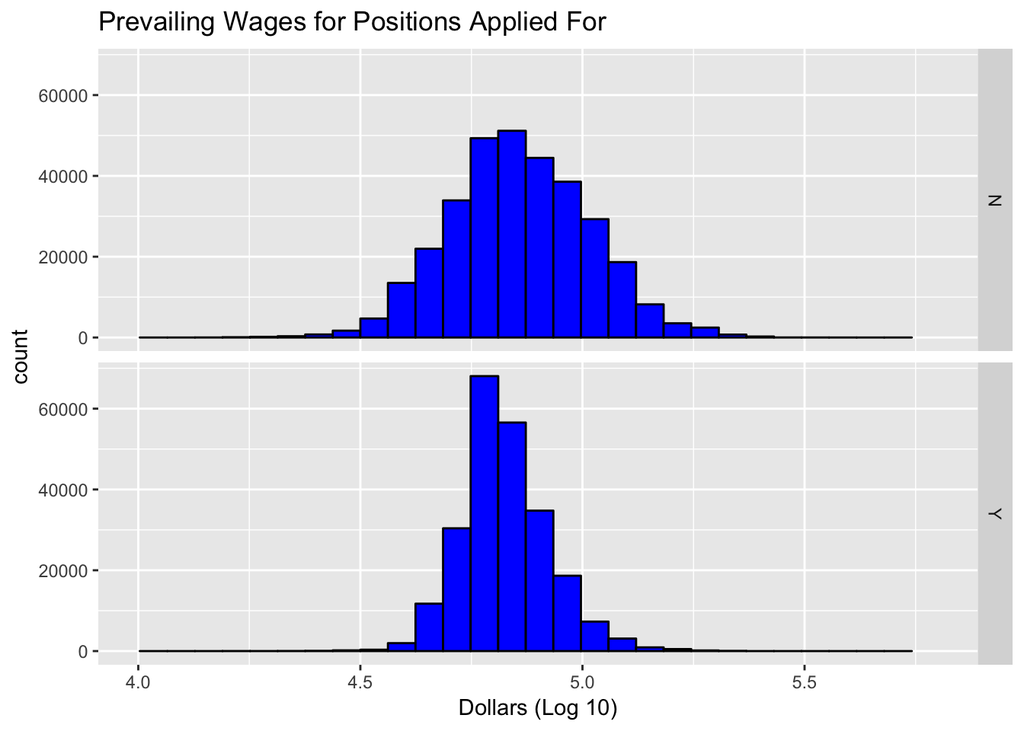

**It does appear that there is a tendency for H1-B non-dependent employers to submit applications for jobs with higher prevailing wages, and a wider variety of job salaries.**

We can verify this by looking at the descriptive statistics (`sd` is standard deviation).

```r
summary(nondependent_employers$PW_ANNUALIZED)
```

```
##    Min. 1st Qu.  Median    Mean 3rd Qu.    Max.
##   14500   56800   71420   77150   92630  488400
```

```r
sd(nondependent_employers$PW_ANNUALIZED)
```

```
## [1] 29291.48
```

```r
summary(dependent_employers$PW_ANNUALIZED)
```

```
##    Min. 1st Qu.  Median    Mean 3rd Qu.    Max.
##   15220   58120   65310   68740   75880  253400
```

```r
sd(dependent_employers$PW_ANNUALIZED)
```

```
## [1] 16904.07
```

### Offered Wages

Likewise applications include data on the wage that will be offered to the worker. These are required to be higher than the prevailing wages (although in 26 out of the 558,438 applications they are not). Here is a plot comparing distributions of annualized offered wages.

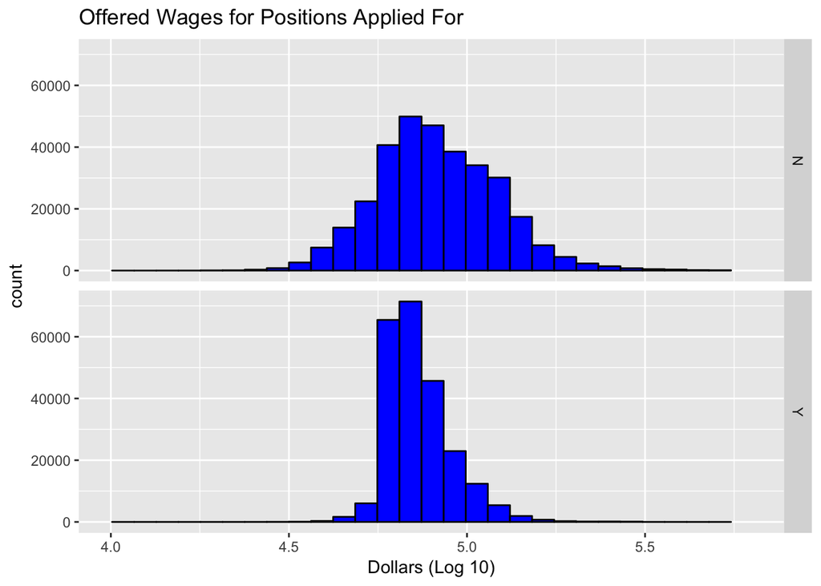

We see the same pattern of higher wages and larger variety for non-dependent employers, in the descriptive statistics.

```r
summary(nondependent_employers$OW_ANNUALIZED)
```

```
##    Min. 1st Qu.  Median    Mean 3rd Qu.    Max.
##   14520   62860   80000   89290  106000  935400
```

```r
sd(nondependent_employers$OW_ANNUALIZED)
```

```
## [1] 41454.41
```

```r
summary(dependent_employers$OW_ANNUALIZED)
```

```
##    Min. 1st Qu.  Median    Mean 3rd Qu.    Max.
##   17140   62500   70000   74820   81000  900000
```

```r
sd(dependent_employers$OW_ANNUALIZED)
```

```
## [1] 19266.79
```

### Are non-dependent employers more generous?

In comparing the difference between offered wages and prevailing wages, the data above suggest that non-dependent employers may be more generous. I would like to test this hypothesis.

The variable `OW_ABOVE_PW` measures the percentage increase/decrease between offered wage and prevailing wage (i.e. the relative difference between these two quantities).

```r
summary(nondependent_employers$OW_ABOVE_PW)
```

```
##     Min.  1st Qu.   Median     Mean  3rd Qu.     Max.
##   -3.846    0.000    6.686   16.330   20.560 1544.000
```

```r
summary(dependent_employers$OW_ABOVE_PW)
```

```
##     Min.  1st Qu.   Median     Mean  3rd Qu.     Max.
##  -21.060    0.000    3.122    9.914   15.140 1460.000
```

To more thoroughly address this question, we use a t-test to compare these distributions.

```r
t.test(nondependent_employers$OW_ABOVE_PW, dependent_employers$OW_ABOVE_PW, paired = FALSE)
```

```
##
##  Welch Two Sample t-test
##
## data:  nondependent_employers$OW_ABOVE_PW and dependent_employers$OW_ABOVE_PW
## t = 96.571, df = 514350, p-value < 2.2e-16
## alternative hypothesis: true difference in means is not equal to 0
## 95 percent confidence interval:
##  6.281357 6.541608
## sample estimates:
## mean of x mean of y
## 16.325290  9.913807
```

From this we can conclude that on average dependent employers will offer a wage that is 9.9% above the prevailing wage, and non-dependent employers will offer a wage that is 16.3% above the prevailing wage. These two percentages are not actually that close together, so we have a very small p-value and a 95% confidence interval far away from zero.